# Sea Ice Indicators Update

##### 2020-12-03

This report presents some updated summary graphics created from the output of the current codebase for defining the freeze-up/break-up indicators.

The “as-coded” current working definitions for each of the indicators are provided in the relevant sections of this document.

# Freeze-up

### Definitions

#### Freeze-up start

Valid date range: 9/1 - 12/31

Threshold is set to the minimum of

1. the sum of the mean and standard deviation of daily summer sea ice concentration (SIC), and 2) 15%.
2. Freeze-up start is defined as the first day the daily SIC exceeds the threshold, unless mean summer SIC is > 25% (then, undefined).

#### Freeze-up end

Valid date range: 9/1 - 2/28

### Totals maps

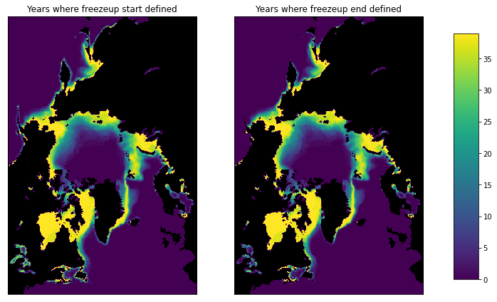

##### Exclusive totals

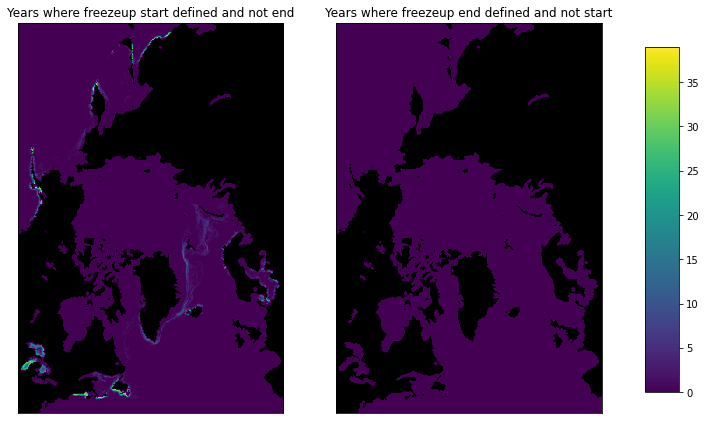

### Mean date histograms

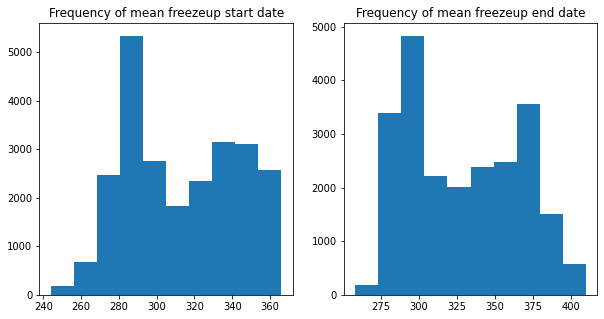

# Break-up

### Definitions

#### Break-up start

Valid date range: 2/1 - 7/31

1. Threshold is set to the mean winter SIC minus 2 standard deviations of the winter SIC.
2. Break-up start is defined as the last day for which previous two weeks are above this threshold if:  
   a. Mean summer SIC is less than 40%.

#### Break-up end

Valid date range: 2/1 - 9/29

1. Threshold is set to the minimum of 1) the sum of the mean and standard deviation of daily summer SIC, and 2) 50%.
2. Break-up end is defined as the first day where the daily SIC is less than the threshold for the following two weeks  
   a. Undefined if daily SIC is less than this threshold for every day of the search period

### Totals maps

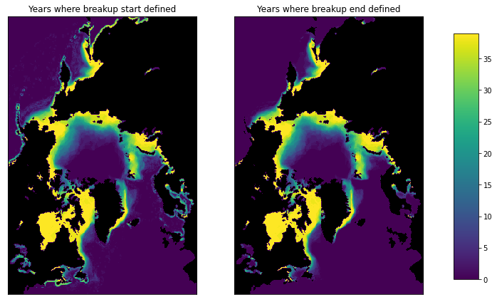

##### Exclusive totals

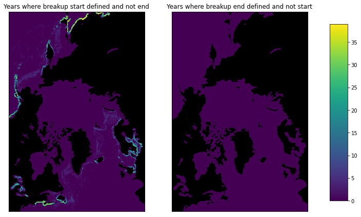

### Mean date histograms

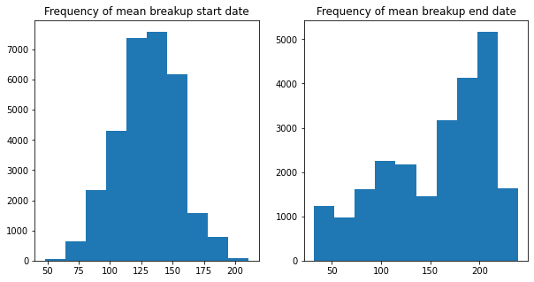